# **Panorama da inflação**

Os principais índices de inflação do Brasil, apontam em dezembro de 2010 um avanço da inflação de em média **0.64%**. Com esse resultado, no ano a inflação acumula uma variação média positiva de **7.67%**, e em 12 meses uma variação média acumulada de **7.90%**.

|  | Variação mensal | Variação acumulada no ano | Variação acumulada em 12 meses |
| --- | --- | --- | --- |
| IPCA | 0.63% | 5.91% | 5.91% |
| INPC | 0.6% | 6.46% | 6.47% |
| IGP-M | 0.69% | 10.63% | 11.32% |
| IGP-DI | 0.38% | 10.19% | 11.3% |
| IPA | 0.21% | 0.14% | 0.14% |
| IPC | 0.72% | 4.88% | 6.24% |
| INCC | 0.67% | 7.09% | 7.77% |

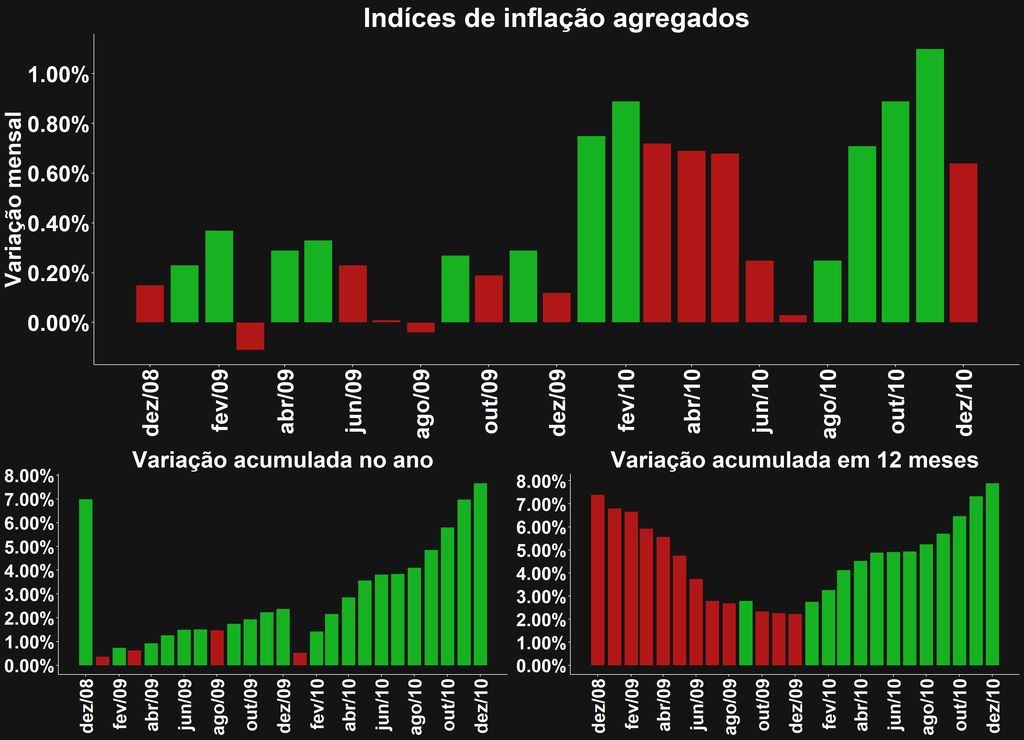

Índices selecionados para a média: IPCA, INPC e IGP-M.

# IPCA

O Indíce de Preços ao Consumidor Amplo (IPCA) variou 0.63% em dezembro, valor superior ao mesmo período do ano anterior quando apresentou uma taxa de 0.37%. Com esse resultado o indíce acumula no ano uma variação positiva de 5.91%, e em 12 meses uma variação positiva de 5.91%.

|  | 12/2009 | 11/2010 | 12/2010 |
| --- | --- | --- | --- |
| Variação mensal | 0.37% | 0.83% | 0.63% |
| Variação acumulada no ano | 4.31% | 5.25% | 5.91% |
| Variação acumulada em 12 meses | 4.31% | 5.63% | 5.91% |

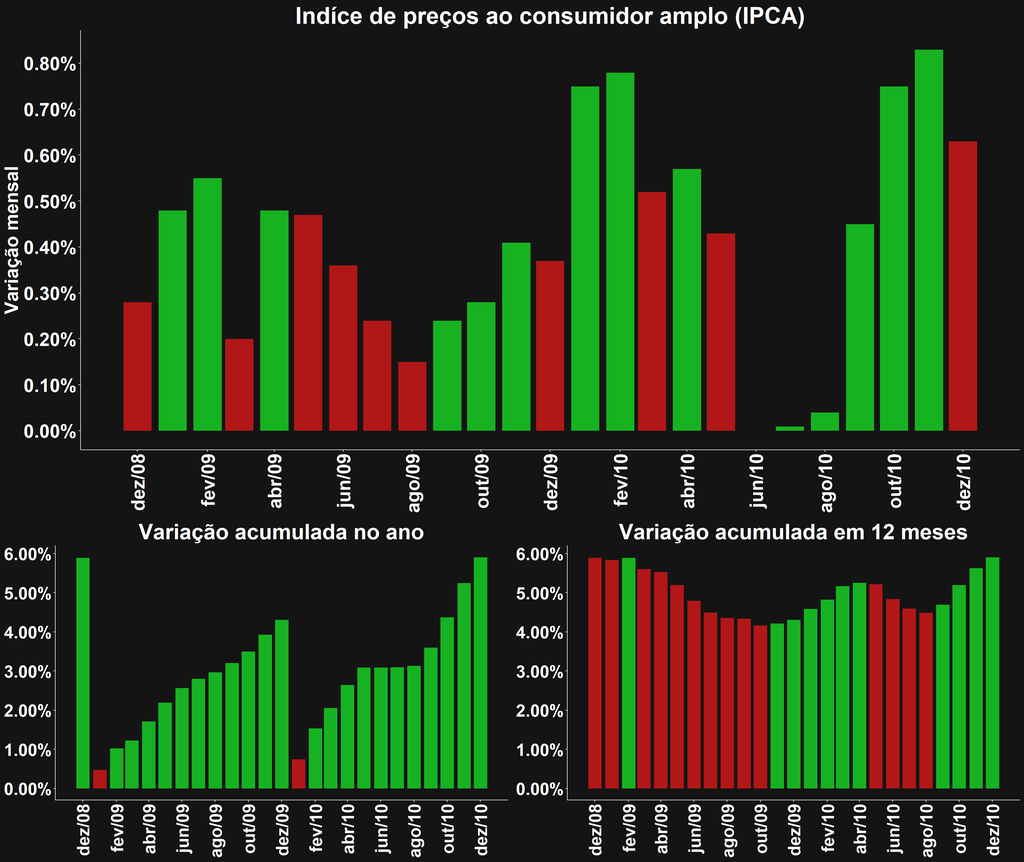

|  | Variação mensal | Variação acumulada no ano | Peso mensal |
| --- | --- | --- | --- |
| Alimentação e bebidas | 1.32% | 10.39% | 23.31% |
| Habitação | 0.49% | 4.98% | 13.24% |
| Artigos de residência | 0.1% | 3.51% | 4.12% |
| Vestuário | 1.34% | 7.51% | 6.8% |
| Transportes | 0.29% | 2.41% | 18.74% |
| Saúde e cuidados pessoais | 0.39% | 5.06% | 10.79% |
| Despesas pessoais | 0.57% | 7.37% | 10.36% |
| Educação | 0.05% | 6.21% | 7.12% |
| Comunicação | 0.05% | 0.86% | 5.52% |

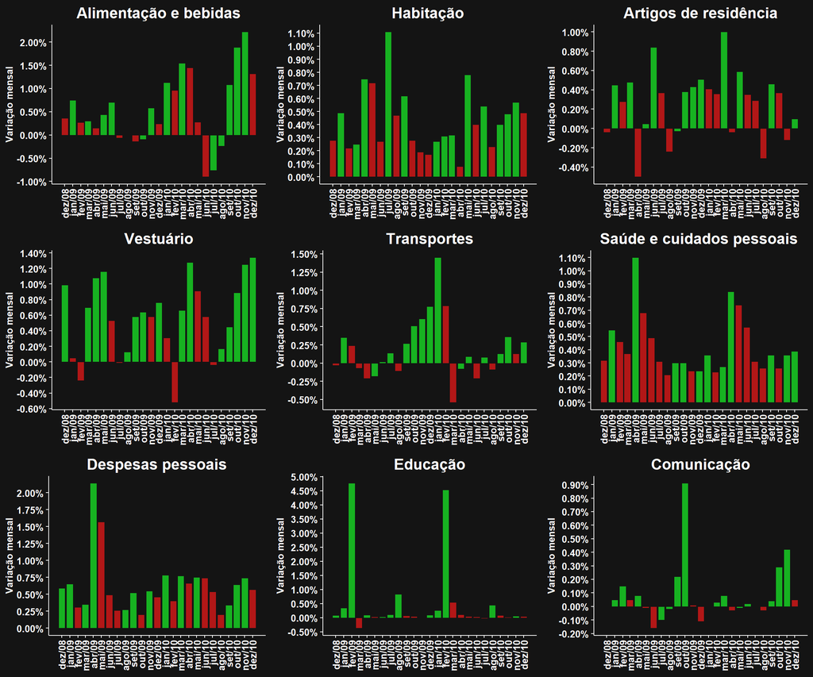

A nível de sub-itens os que mais influenciaram positivamente no resultado em relação ao seu peso foram Refeição (1.98%%) e Lanche (2.02%%), e negativamente Feijão - carioca (rajado)) (-16.45%%) e Batata-inglesa (-11.96%%).

|  | Variação mensal | Variação acumulada no ano | Peso mensal |
| --- | --- | --- | --- |
| Passagem aérea | 7.61% | 3.15% | 0.34% |
| Frango inteiro | 4.81% | 14.71% | 0.62% |
| Lanche | 2.02% | 9.58% | 1.68% |
| Refeição | 1.98% | 10.61% | 4.45% |

|  | Variação mensal | Variação acumulada no ano | Peso mensal |
| --- | --- | --- | --- |
| Automóvel usado | -0.86% | -2.01% | 1.17% |
| Batata-inglesa | -11.96% | -22.31% | 0.2% |
| Feijão - carioca (rajado)) | -16.45% | 63.65% | 0.28% |
| Melancia | -19.13% | 4.57% | 0.06% |

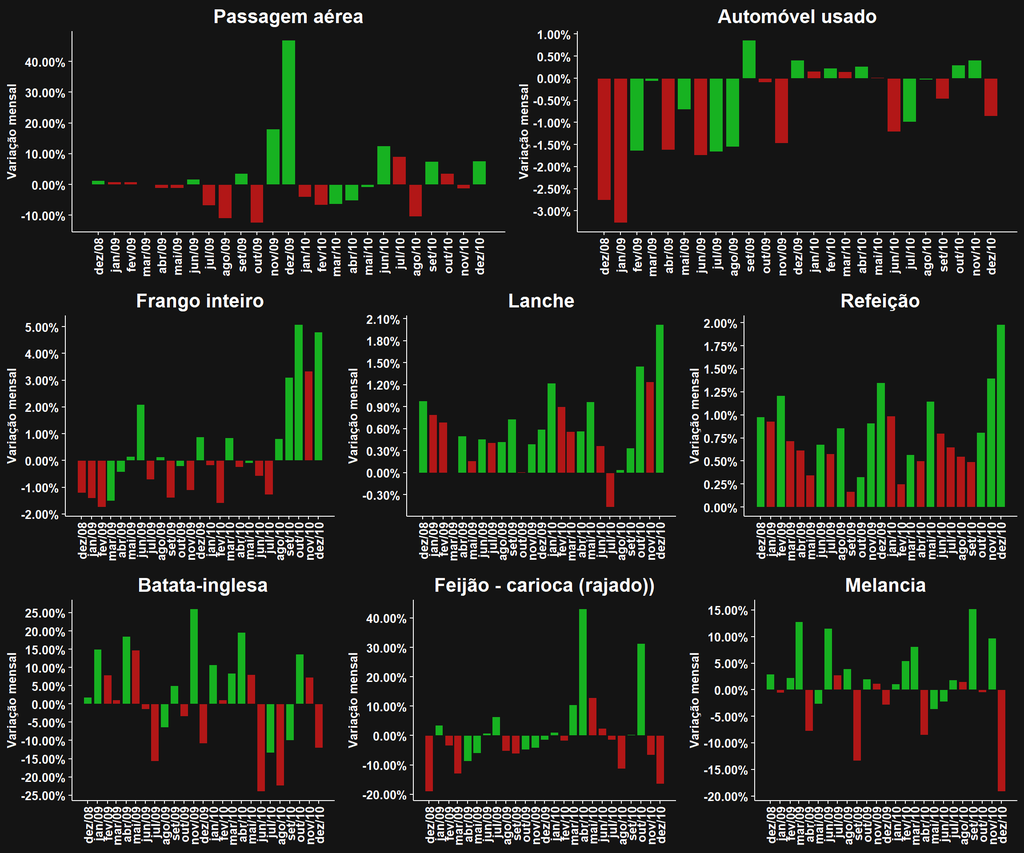

# INPC

O Indíce Nacional de Preços ao Consumidor (INPC) variou 0.6% em dezembro, valor superior ao mesmo período do ano anterior quando apresentou uma taxa de 0.24%. Com esse resultado o indíce acumula no ano uma variação positiva de 6.46%, e em 12 meses uma variação positiva de 6.47%.

|  | 12/2009 | 11/2010 | 12/2010 |
| --- | --- | --- | --- |
| Variação mensal | 0.24% | 1.03% | 0.6% |
| Variação acumulada no ano | 4.11% | 5.83% | 6.46% |
| Variação acumulada em 12 meses | 4.11% | 6.08% | 6.47% |

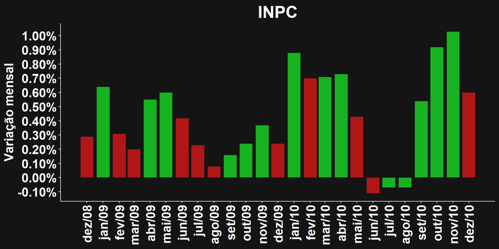

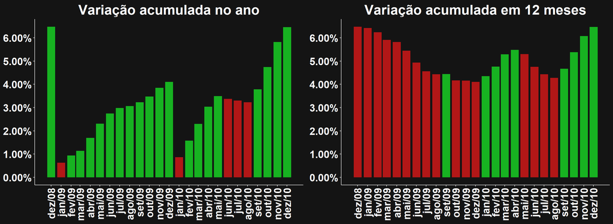

# IGP-M

O Indíce Geral de Preços de Mercado (IGP-M) variou 0.69% em dezembro, valor superior ao mesmo período do ano anterior quando apresentou uma taxa de -0.26%. Com esse resultado o indíce acumula no ano uma variação positiva de 10.63%, e em 12 meses uma variação positiva de 11.32%.

|  | 12/2009 | 11/2010 | 12/2010 |
| --- | --- | --- | --- |
| Variação mensal | -0.26% | 1.45% | 0.69% |
| Variação acumulada no ano | -1.29% | 9.87% | 10.63% |
| Variação acumulada em 12 meses | -1.72% | 10.27% | 11.32% |

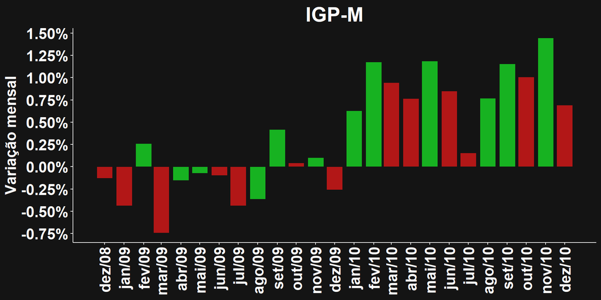

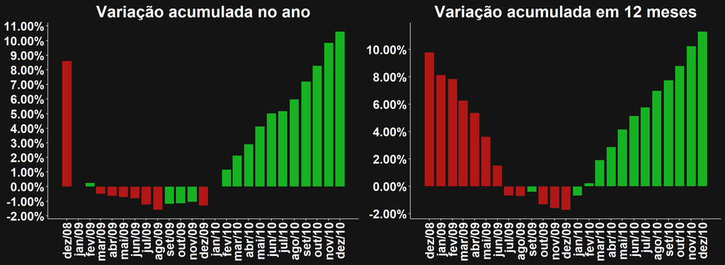

# IGP-DI

O Indíce Geral de Preços - Disponibilidade Interna (IGP-DI) variou 0.38% em dezembro, valor superior ao mesmo período do ano anterior quando apresentou uma taxa de -0.11%. Com esse resultado o indíce acumula no ano uma variação positiva de 10.19%, e em 12 meses uma variação positiva de 11.3%.

|  | 12/2009 | 11/2010 | 12/2010 |
| --- | --- | --- | --- |
| Variação mensal | -0.11% | 1.58% | 0.38% |
| Variação acumulada no ano | -1.44% | 9.77% | 10.19% |
| Variação acumulada em 12 meses | -1.43% | 10.75% | 11.3% |

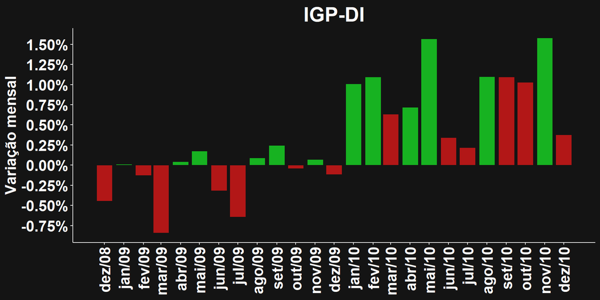

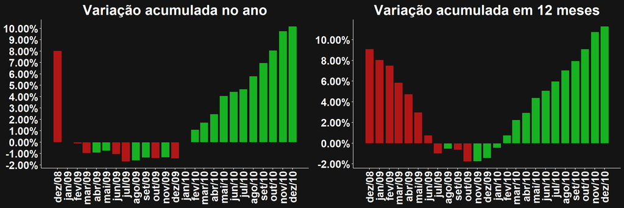

|  | 12/2009 | 11/2010 | 12/2010 |
| --- | --- | --- | --- |
| Variação mensal | -0.29% | 1.98% | 0.21% |
| Variação acumulada no ano | -0.04% | 0.14% | 0.14% |
| Variação acumulada em 12 meses | -0.04% | 0.13% | 0.14% |

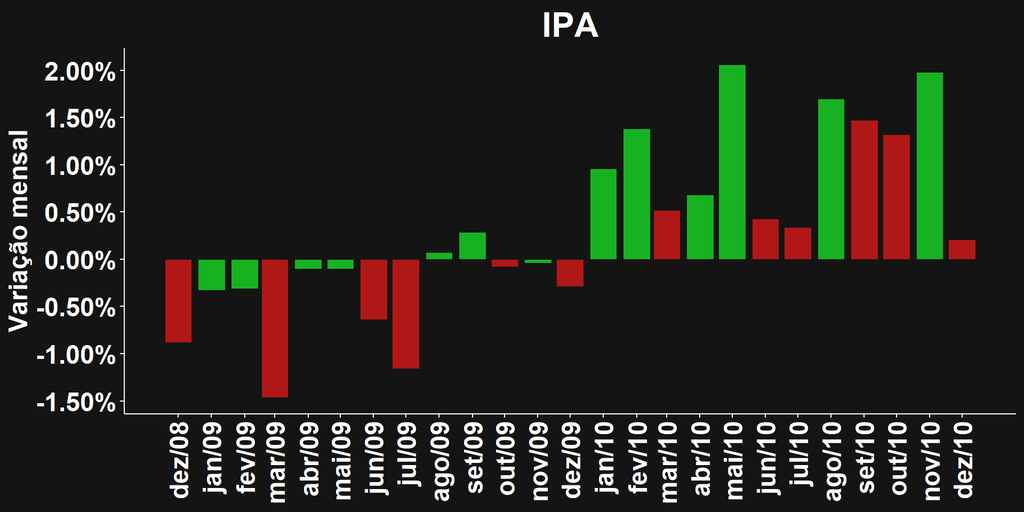

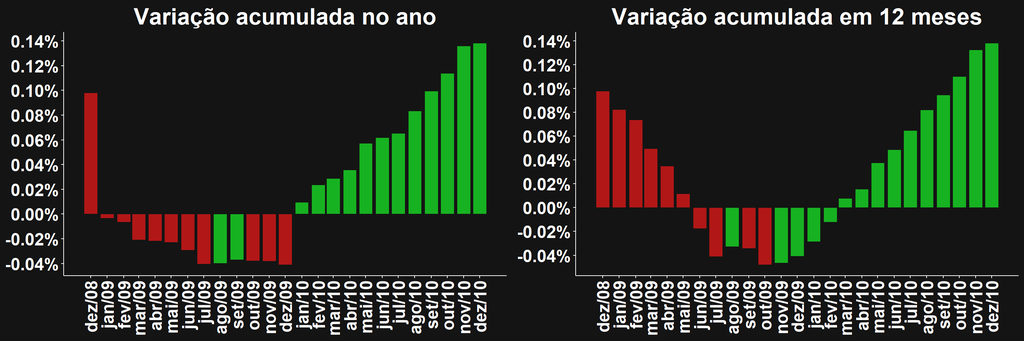

O Indíce de Preços ao Consumidor (IPC), integrante do IGP-DI com peso de 30%, apresentou variação de 0.72% em dezembro, valor superior ao mesmo período do ano anterior quando apresentou uma taxa de 0.24%. Com esse resultado o indíce acumula no ano uma variação positiva de 4.88%, e em 12 meses uma variação positiva de 6.24%.

|  | 12/2009 | 11/2010 | 12/2010 |
| --- | --- | --- | --- |
| Variação mensal | 0.24% | 1% | 0.72% |
| Variação acumulada no ano | 3.09% | 4.13% | 4.88% |
| Variação acumulada em 12 meses | 3.95% | 5.73% | 6.24% |

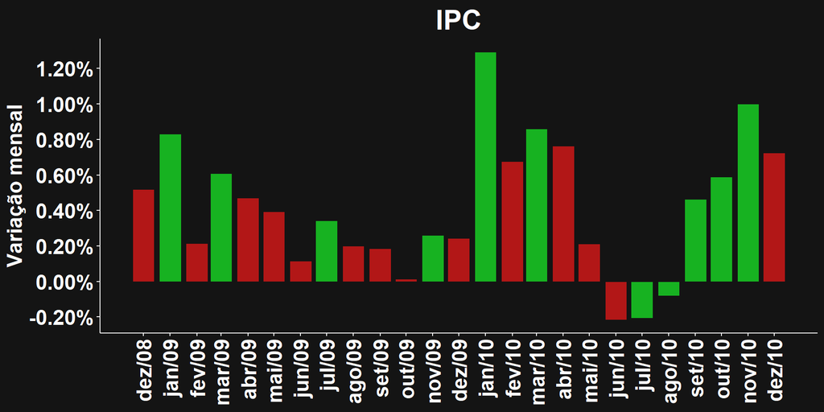

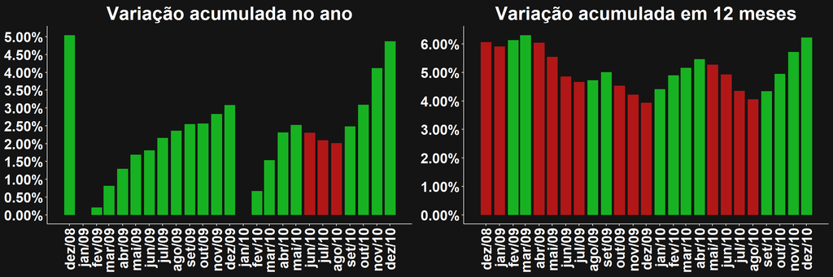

O Indíce Nacional de Custos de Construção (INCC), integrante do IGP-DI com peso de 10%, apresentou variação de 0.67% em dezembro, valor superior ao mesmo período do ano anterior quando apresentou uma taxa de 0.1%. Com esse resultado o indíce acumula no ano uma variação positiva de 7.09%, e em 12 meses uma variação positiva de 7.77%.

|  | 12/2009 | 11/2010 | 12/2010 |
| --- | --- | --- | --- |
| Variação mensal | 0.1% | 0.37% | 0.67% |
| Variação acumulada no ano | 2.9% | 6.38% | 7.09% |
| Variação acumulada em 12 meses | 3.25% | 7.16% | 7.77% |

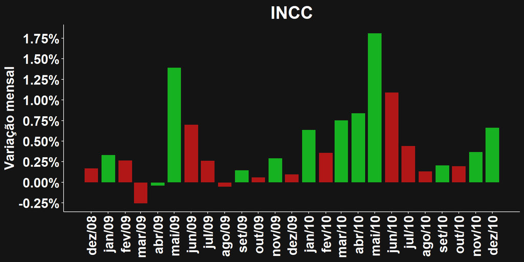

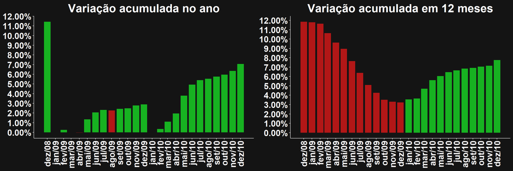

# Estatísticas

As estatísticas descritivas a seguir são feitas com base nos últimos 48 meses, e tem como objetivo possibilitar a avaliação do resultado observado em comparação aos períodos anteriores.

|  | Minimo | 1 Quartil | Mediana | Media | 3 Quartil | Maximo | Desvio Padrão |
| --- | --- | --- | --- | --- | --- | --- | --- |
| IPCA | 0% | 0.28% | 0.44% | 0.42% | 0.53% | 0.83% | 0.2% |
| INPC | -0.11% | 0.26% | 0.43% | 0.45% | 0.61% | 1.03% | 0.28% |
| IGP-M | -0.74% | 0.04% | 0.52% | 0.54% | 0.99% | 1.98% | 0.64% |
| IGP-DI | -0.84% | 0.09% | 0.38% | 0.54% | 1.09% | 1.89% | 0.65% |
| IPA | -1.46% | -0.05% | 0.42% | 0.57% | 1.33% | 2.29% | 0.92% |
| IPC | -0.21% | 0.21% | 0.42% | 0.42% | 0.68% | 1.29% | 0.33% |
| INCC | -0.26% | 0.26% | 0.45% | 0.58% | 0.79% | 2.02% | 0.51% |

Levando em consideração o desvio padrão de cada indíce, proporcionalmente os que mais se afastaram da média foram o IPCA, o IPC e o INPC.

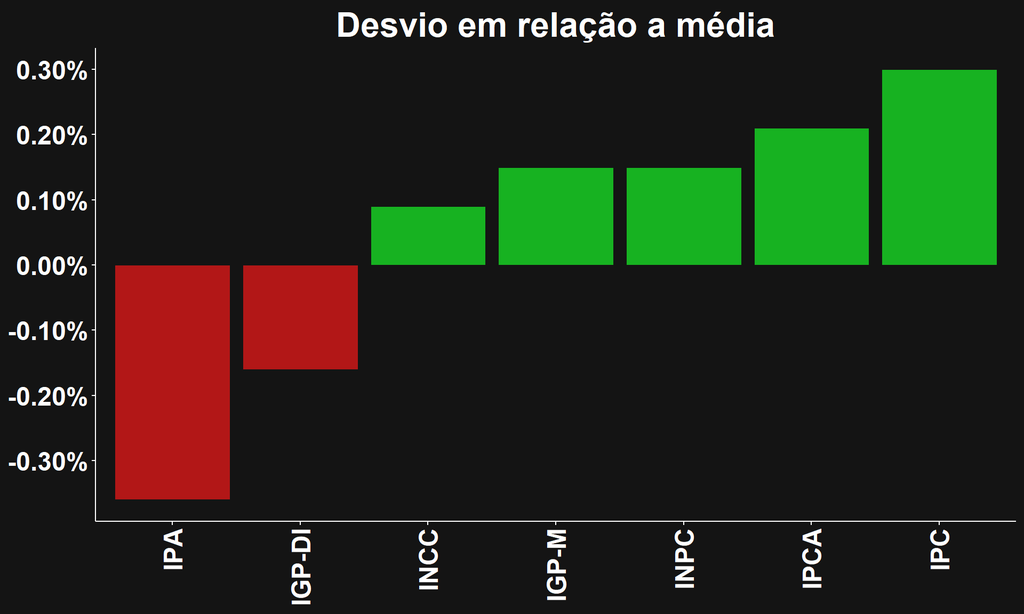

**João Victor Gomes**  
**jvg.santana@gmail.com**  
**[linkedin.com/in/jvictorgomes](https://www.linkedin.com/in/jvictorgomes/)**